# Установка и настройка операционной системы

Отчет по лабораторной работе №1

Садыков Ильдар Ильфатович

sad.ildar0406@gmail.com

Российский университет дружбы народов

2026-03-03

# Вводная часть

## Актуальность

- Операционная система — основа взаимодействия пользователя с компьютером
- Умение устанавливать и настраивать ОС необходимо для любого специалиста в области IT
- Навыки работы с виртуальными машинами позволяют изучать различные ОС без риска для основной системы

## Объект и предмет исследования

- Объект исследования: процесс установки операционной системы
- Предмет исследования: дистрибутив Fedora Sway и виртуальная машина VirtualBox

## Цели и задачи

**Цель:** Приобретение практических навыков установки операционной системы на виртуальную машину, настройка минимально необходимых для дальнейшей работы сервисов.

**Задачи:** 1. Установить дистрибутив Fedora Sway. 2. Выполнить базовую настройку системы. 3. Установить ПО для создания документации. 4. Проанализировать загрузку системы с помощью команды `dmesg`.

## Материалы и методы

- **Оборудование:** ПК с ОС Windows/Linux
- **ПО:** VirtualBox, образ Fedora Sway
- **Методы:** Установка по руководству, настройка через терминал, анализ логов системы

# Выполнение лабораторной работы

## Создание виртуальной машины

- Создан каталог для ВМ в VirtualBox
- Настроена ОС, подключен образ Fedora Sway для установки

## Установка операционной системы

- Выполнен запуск ВМ и установка ОС
- Настроен профиль пользователя (логин: `iisadykov`)
- Заданы пароль и язык системы

## После установки: базовая настройка

- Выполнен вход в систему
- Установлены:
  - Средства разработки
  - Обновленные пакеты
  - `tmux`
- Отключен SELinux
- Настроена русская раскладка (переключение на правый `ctrl`)
- Задано имя хоста: `iisadykov`

## После установки: ПО для документации

- Установлено программное обеспечение для создания отчетов:
  - `pandoc` и `pandoc-crossref`
  - `quarto`
  - `texlive`

# Анализ системы (домашнее задание)

## Версия ядра Linux

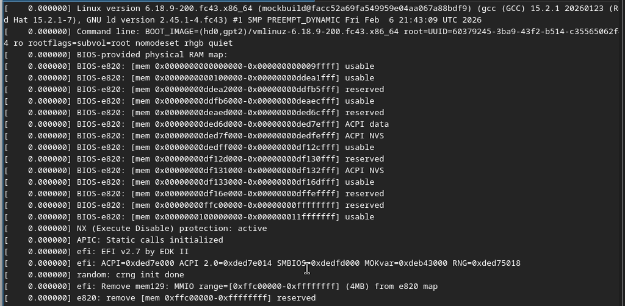

Рисунок 1: Версия ядра

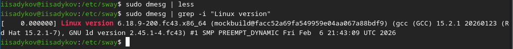

## Модель процессора

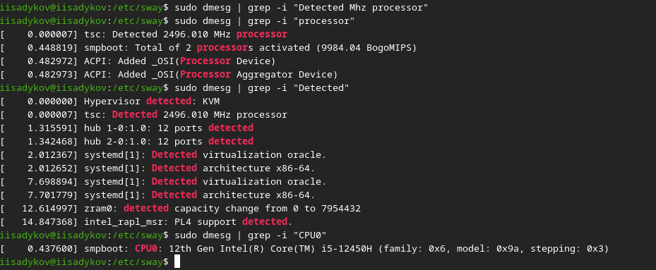

Рисунок 3: Модель процессора

## Объем оперативной памяти (ОЗУ)

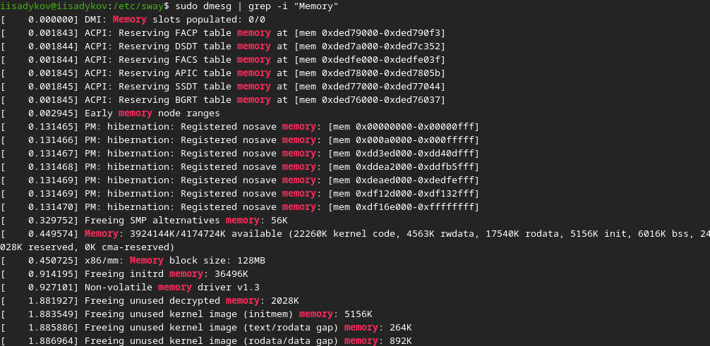

Рисунок 4: Объем ОЗУ

## Тип гипервизора

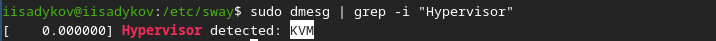

Рисунок 5: Гипервизор

## Последовательность монтирования файловых систем

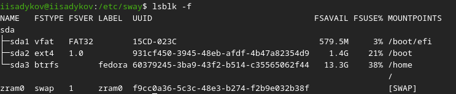

Рисунок 6: Последовательность монтирования

# Выводы

## Выводы

- В ходе выполнения лабораторной работы была достигнута поставленная цель
- Приобретены навыки установки ОС на виртуальную машину
- Освоены базовые команды настройки системы и анализа ее загрузки
- Подготовлена среда для выполнения последующих лабораторных работ